# Final_Project_BRFSS_Data

Pedram Torabian

26/02/2022

## Setup

### Load packages

```r
library(ggplot2)
library(dplyr)
library(tidyverse)
```

### Load data

```r
load("brfss2013.RData")
```

## Part1: Data

##In this project, we have The Behavioral Risk Factor Surveillance System (BRFSS) data originating from the Centers for Disease Control and Prevention (CDC) and US citizens. This data has been gathered to measure behavioral risk factors for the non-institutionalized adult population (18 years of age and older) residing in the US.

##Reference: BRFSS web site: http://www.cdc.gov/brfss

## Part 2: Research questions

**Research quesion 1:**

## What is the relationship between the age of onset and affected by Asthma?

#In this question, we are looking for the relationship between the diganosis age of Asthma among population.

#First I want to attach the data

```r
attach(brfss2013)
```

#Then, we should remove NAs

```r
brfss2013_cleansed1 <- brfss2013%>%
  filter(!is.na(asthmage))
```

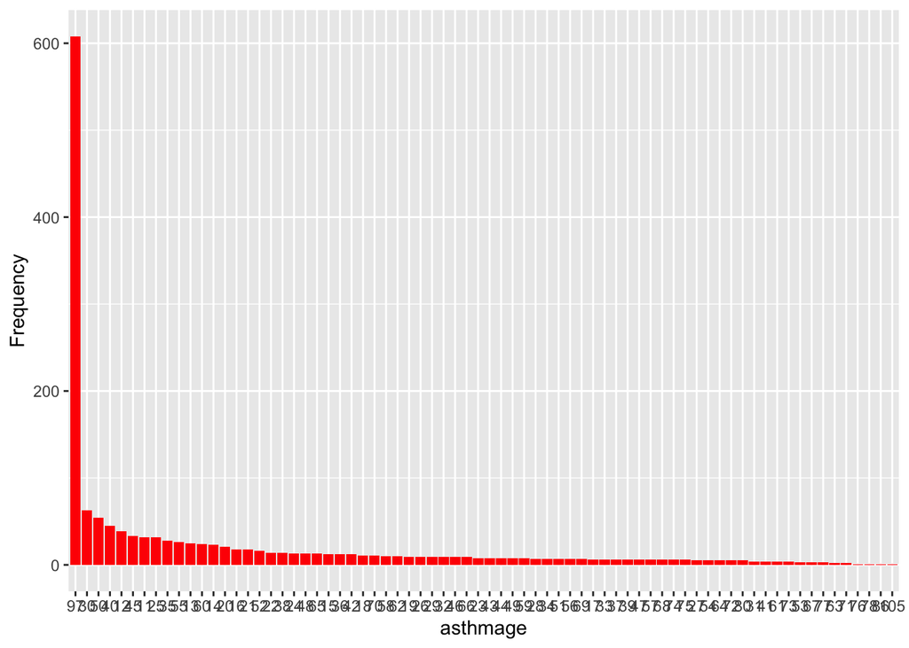

```r
ggplot(brfss2013_cleansed1,
       aes(x = reorder(asthmage, asthmage, function(x)-length(x)))) +
  geom_bar(fill='red') + labs(x='asthmage', y='Frequency')
```

#Results: As it seems in the plot, most affected people are young ones, especially those who are below the age of 10 (number 97 represents the people who are 10 years old or younger). Therefore, I may conclude that there might be some genetic factors involved in this disease as most people are belonged to their early ages and this hypothesis should be further investigated.

**Research quesion 2:**

## Is there any relationship between the level of income and level of satisfaction among people?

#In this question, I attempted to catagorized people’s income based in level of $K and four classes of satisfaction.

```r
brfss2013<- brfss2013%>%
mutate(income_based_on_K= ifelse(X_incomg=="Less than $15,000","$0-$15K",ifelse(X_incomg=="$15,000 to less than $25,000","$15K-$25K",ifelse(X_incomg=="$25,000 to less than $35,000","$25K-$35K",ifelse(X_incomg=="$35,000 to less than $50,000","$35K-$50K",">$50K")))))
```

```r
income_level_of_satisfaction <- brfss2013%>%
  filter(!is.na(income_based_on_K), !is.na(lsatisfy))%>%
  group_by(income_based_on_K,lsatisfy)%>%
  summarise(number=n())
```

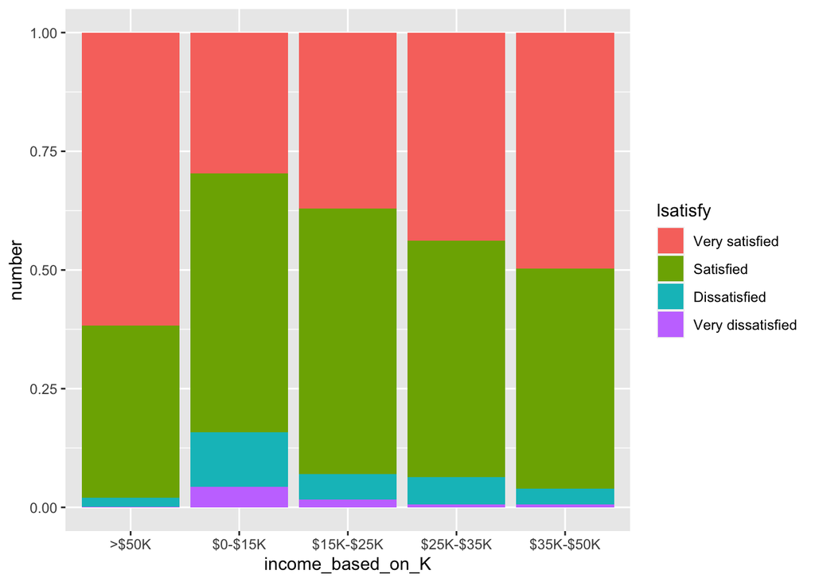

```r
ggplot(income_level_of_satisfaction,
       aes(x = income_based_on_K, y = number, fill = lsatisfy)) +
  geom_bar(position = "fill", stat = "identity")
```

**Research quesion 3:**

[figure not shown]

```r
menthlthslp <- brfss2013%>%
  filter(sleptim1 %in% c(1:20),!is.na(menthlth))%>%
  group_by(sleptim1)%>%
  summarise(poormnthlth= mean(menthlth))

menthlthslp <- brfss2013%>%
filter(sleptim1 %in% c(1:20),!is.na(physhlth))%>%
group_by(sleptim1)%>%
summarise(poormnthlth= mean(physhlth))

ggplot(menthlthslp, aes(x= sleptim1, y= poormnthlth))+geom_point(color="blue")+geom_line(color="red")+
  ggtitle("The Relationship between Sleep duration and Level of Mental Health") +
  xlab("Sleep") + ylab("Mental Helath")+  geom_smooth(method=lm, level = 0.01, col='black', size=1)
```